# Extrapolating $CH_4$ Emission for USA, Germany and New Zeeland

Linus Benetz

2026-07-27

```r
rm(list = ls())

library("rio")
library("here")
library("readxl")
library("tidyr")
library("dplyr")
library("ggplot2")
library("viridis")
library("janitor")
library("purrr") # für map Befehl
library("tidyverse")
library("ggpmisc")
library("patchwork")
library("ggtext")
library("scales") # maskiert col_factor readr; discard von purrr; viridis_pal von viridis
#-> muss wenn ich die aus den anderen Pakten haben will direkt ansprechen mit viridis::vidis_pal

source(here::here("04_visual/R_Skripte", "Time_series_Sectors_extrapol_function.r"))

here()
```

# General

Here, the CH4 data Emission data for all sectors will be analysed as a time sereies lot, for all three project countrys. The data is collected from the published CRT tables, where USA are available through 2022 and NZL & DEU through 2024.

# Germany - DEU

### Table import

The emission sector **Other** is not relevant and without any $CH_4$ emission for Germany. Also the sector **Agriculture** has only three subcatagories with emission values for Germany: **Enteric fermentation**, **Manure management** & **Other**.

```r
DEU_CH4_all_sectors <- import(
  file = here("02_processed/Sector_Emis_data", "CH4_all_Emis_Sectors_DEU_90_24.csv")
)

summary(DEU_CH4_all_sectors)

DEU_CH4_Agric_Sect <- import(
  file = here("02_processed/Sector_Emis_data", "CH4_Emis_Sector_AGRICULTURE_DEU_90_24.csv")
)

summary(DEU_CH4_Agric_Sect)
```

### Creating Time-series Plot

Using function from implented source. The time sereis for **Other** will not be shown, because only *NA*.

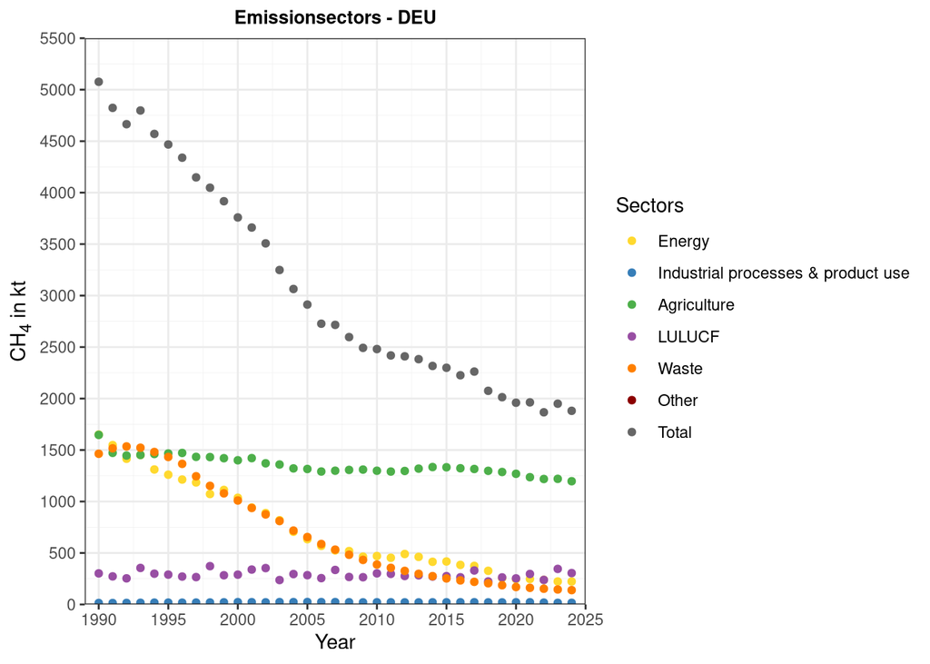

```r
DEU_CH4_all_Sectors_plot <- All_sectors_CC_specific_function(df = DEU_CH4_all_sectors, lm = 5.5, br_lm = 6, bei = 0.5, CC = "DEU")

ggsave(file = here("04_visual/first_try/time_series/Emission_sectors/All_Sectors", "All_sectors_DEU.pdf"),
       plot = DEU_CH4_all_Sectors_plot)

DEU_CH4_all_Sectors_plot
```

###### NA-Filter

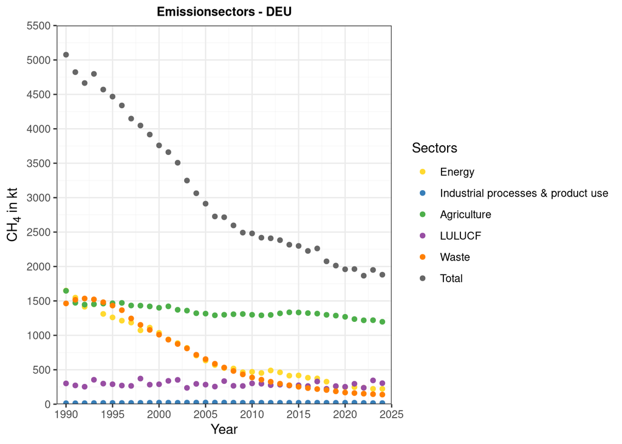

```r
DEU_CH4_all_Sectors_NA_filt <- All_sectors_CC_specific_NA_Filter_function(df = DEU_CH4_all_sectors, lm = 5.5, br_lm = 6, bei = 0.5, CC = "DEU")

ggsave(file = here("04_visual/first_try/time_series/Emission_sectors/All_Sectors", "All_sectors_DEU_NA_filtered.pdf"),
       plot = DEU_CH4_all_Sectors_NA_filt)

DEU_CH4_all_Sectors_NA_filt
```

### Agriculture Sector

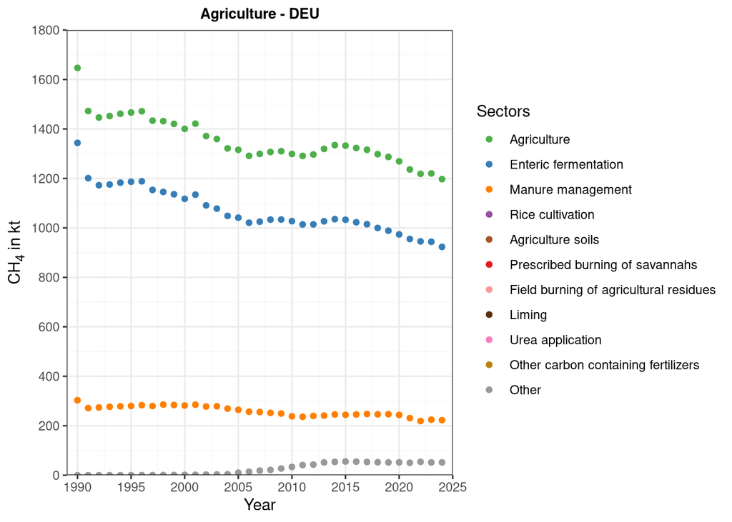

```r
DEU_CH4_AGR_Sec_plot <- Agriculture_sect_CC_specific_function(df = DEU_CH4_Agric_Sect, lm = 1.8, br_lm = 2, bei = 0.2, CC = "DEU")

ggsave(file = here("04_visual/first_try/time_series/Emission_sectors/AGR_SEC", "AGR_sec_DEU.pdf"),
       plot = DEU_CH4_AGR_Sec_plot)

DEU_CH4_AGR_Sec_plot
```

##### NA-Filter

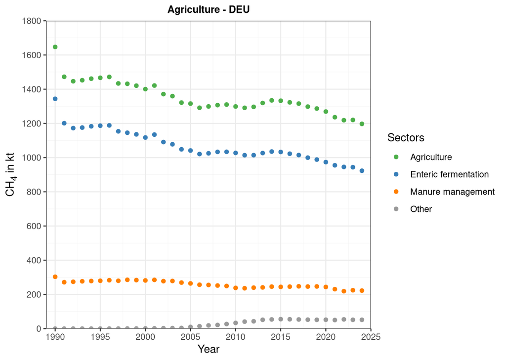

```r
DEU_CH4_AGR_Sec_NA_filt_plot <- Agriculture_sect_CC_specific_NA_filter_function(df = DEU_CH4_Agric_Sect, lm = 1.8, br_lm = 2, bei = 0.2, CC = "DEU")

ggsave(file = here("04_visual/first_try/time_series/Emission_sectors/AGR_SEC", "AGR_sec_DEU_NA_filtered.pdf"),
       plot = DEU_CH4_AGR_Sec_NA_filt_plot)

DEU_CH4_AGR_Sec_NA_filt_plot
```

# United States - USA

### Table import

```r
USA_CH4_all_sectors <- import(
  file = here("02_processed/Sector_Emis_data", "CH4_all_Emis_Sectors_USA_90_22.csv")
)

summary(USA_CH4_all_sectors)

USA_CH4_AGRICULTURE_Sector <- import(
  file = here("02_processed/Sector_Emis_data", "CH4_Emis_Sector_AGRICULTURE_USA_90_22.csv")
)

summary(USA_CH4_AGRICULTURE_Sector)
```

### Creating Time-series Plot

Using function from implented source. The time sereis for **Other** will not be shown, because only *NA*.

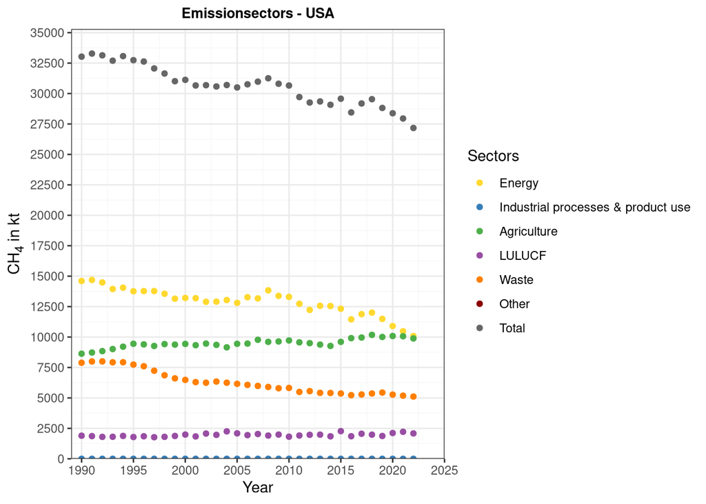

```r
USA_CH4_all_Sectors <- All_sectors_CC_specific_function(df = USA_CH4_all_sectors, lm = 35.3, br_lm = 35, bei = 2.5, CC = "USA")

ggsave(file = here("04_visual/first_try/time_series/Emission_sectors/All_Sectors", "All_sectors_USA.pdf"),
       plot = USA_CH4_all_Sectors)

USA_CH4_all_Sectors
```

##### NA-Filter

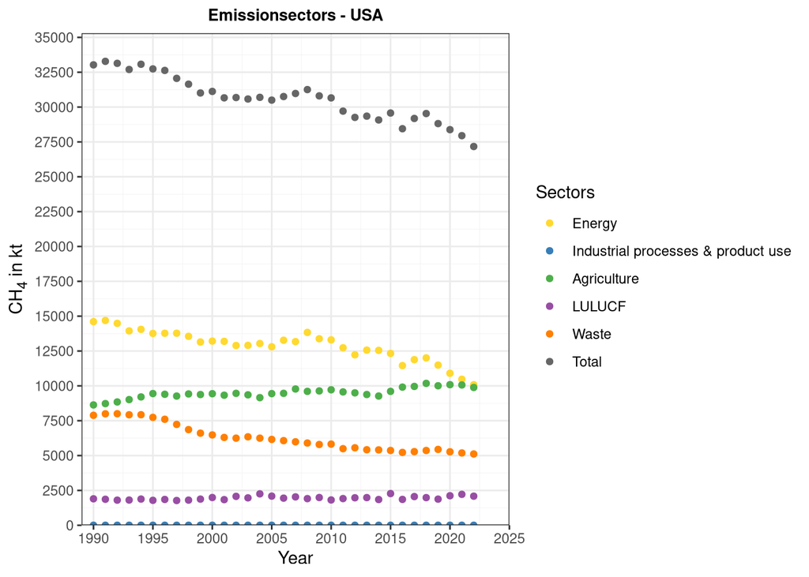

```r
USA_CH4_all_Sectors_NA_flit <- All_sectors_CC_specific_NA_Filter_function(df = USA_CH4_all_sectors, lm = 35.3, br_lm = 35, bei = 2.5, CC = "USA")

ggsave(file = here("04_visual/first_try/time_series/Emission_sectors/All_Sectors", "All_sectors_USA_NA_filtered.pdf"),
       plot = USA_CH4_all_Sectors_NA_flit)

USA_CH4_all_Sectors_NA_flit
```

### Agriculture-Sector

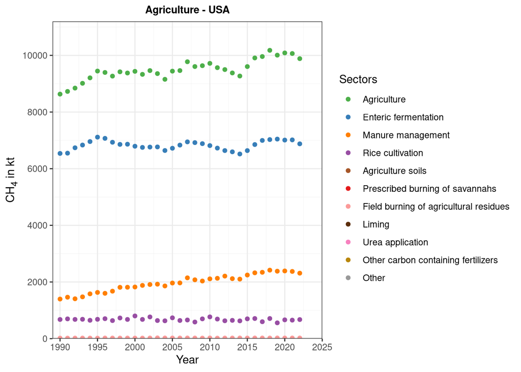

```r
USA_CH4_AGR_Sec_plot <- Agriculture_sect_CC_specific_function(df = USA_CH4_AGRICULTURE_Sector, lm = 11.2, br_lm = 12, bei = 2, CC = "USA")

ggsave(file = here("04_visual/first_try/time_series/Emission_sectors/AGR_SEC", "AGR_sec_USA.pdf"),
       plot = USA_CH4_AGR_Sec_plot)

USA_CH4_AGR_Sec_plot
```

##### NA-Filter

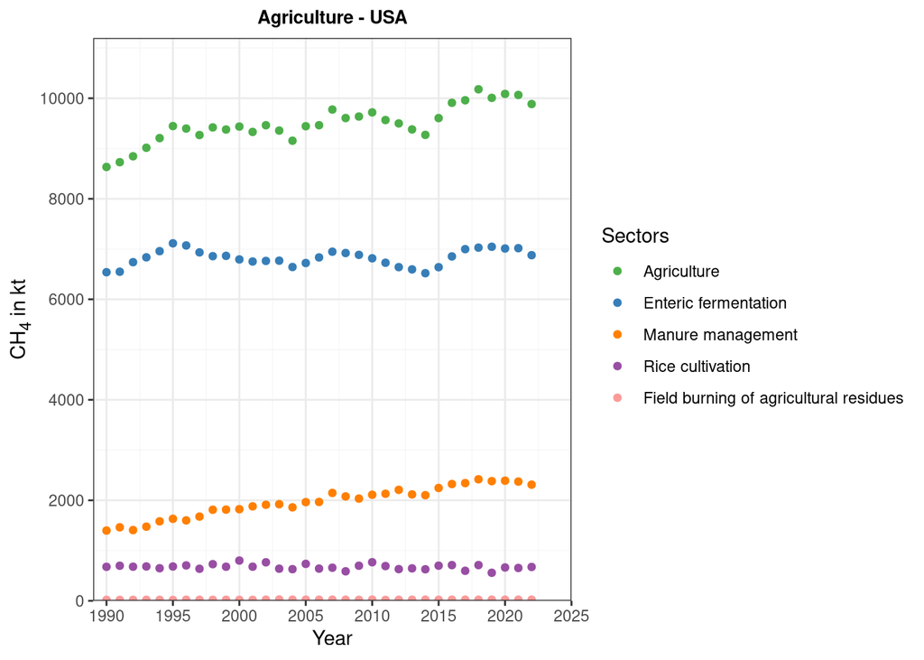

```r
USA_CH4_AGR_Sec_NA_filt_plot <- Agriculture_sect_CC_specific_NA_filter_function(df = USA_CH4_AGRICULTURE_Sector, lm = 11.2, br_lm = 12, bei = 2, CC = "USA")

ggsave(file = here("04_visual/first_try/time_series/Emission_sectors/AGR_SEC", "AGR_sec_USA_NA_filtered.pdf"),
       plot = USA_CH4_AGR_Sec_NA_filt_plot)

USA_CH4_AGR_Sec_NA_filt_plot
```

# New Zeeland - NZL

### Table import

```r
NZL_CH4_all_sectors <- import(
  file = here("02_processed/Sector_Emis_data", "CH4_all_Emis_Sectors_NZL_90_24.csv")
)

summary(NZL_CH4_all_sectors)

NZL_CH4_AGRICULTURE_Sector <- import(
  file = here("02_processed/Sector_Emis_data", "CH4_Emis_Sector_AGRICULTURE_NZL_90_24.csv")
)

summary(NZL_CH4_AGRICULTURE_Sector)
```

### Creating Time-series Plot

Using function from implented source. NZL has values for **Other**, but its really little. Also **Industrial processes & product use** and **LULUCF** have verry little emission, because of that these sectors lay over each other and **Other** hides them.

Becuase of the little values of **LULUCF** the **Total with LULUCF** hides the **Total without LULUCF**.

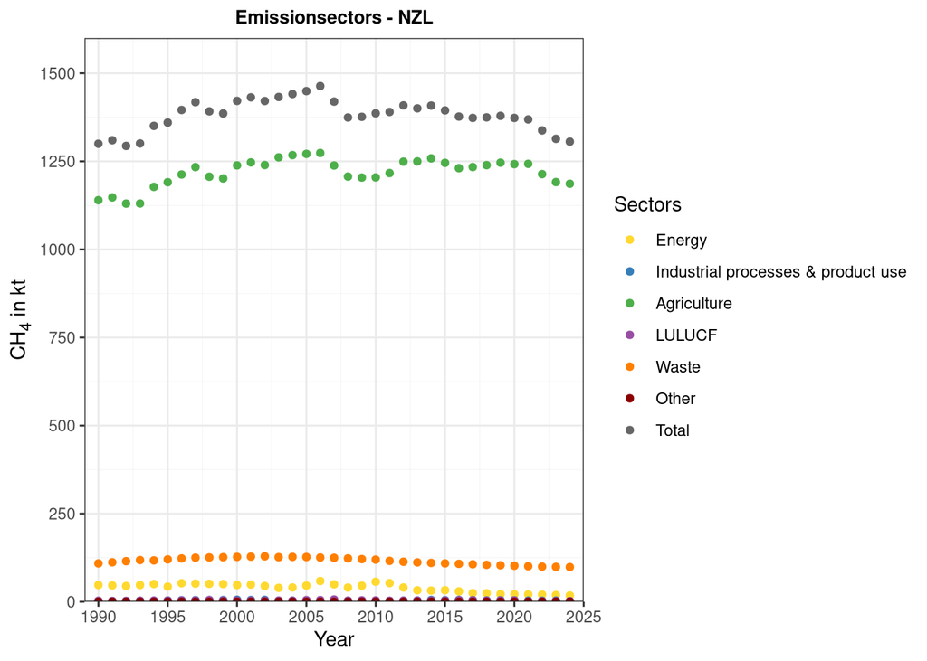

```r
NZL_CH4_all_Sectors <- All_sectors_CC_specific_function(df = NZL_CH4_all_sectors, lm = 1.6, br_lm = 2, bei = 0.25, CC = "NZL")

ggsave(file = here("04_visual/first_try/time_series/Emission_sectors/All_Sectors", "All_sectors_NZL.pdf"),
       plot = NZL_CH4_all_Sectors)

NZL_CH4_all_Sectors
```

##### NA-Filter

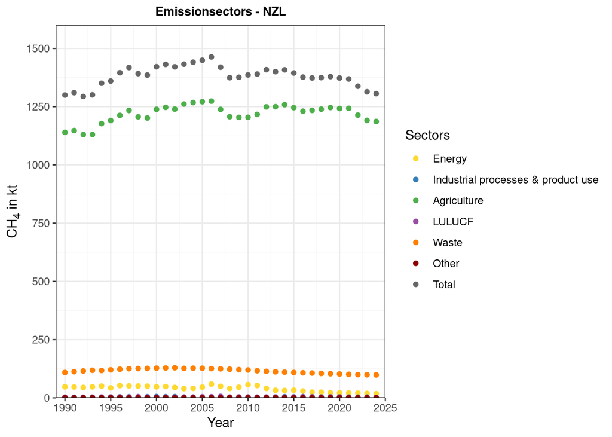

```r
NZL_CH4_all_Sectors_NA_filt <- All_sectors_CC_specific_NA_Filter_function(df = NZL_CH4_all_sectors, lm = 1.6, br_lm = 2, bei = 0.25, CC = "NZL")

ggsave(file = here("04_visual/first_try/time_series/Emission_sectors/All_Sectors", "All_sectors_NZL_NA_filtered.pdf"),
       plot = NZL_CH4_all_Sectors)

NZL_CH4_all_Sectors_NA_filt
```

### Agriculture - Sector

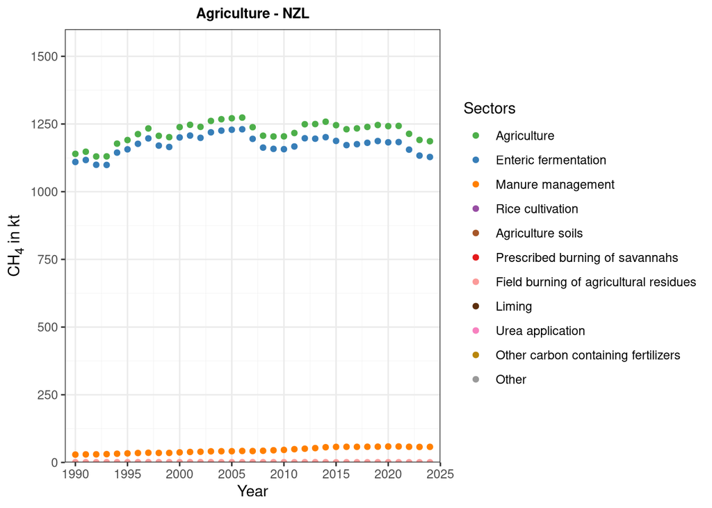

```r
NZL_CH4_AGR_Sec_plot <- Agriculture_sect_CC_specific_function(df = NZL_CH4_AGRICULTURE_Sector, lm = 1.6, br_lm = 2, bei = 0.25, CC = "NZL")

ggsave(file = here("04_visual/first_try/time_series/Emission_sectors/AGR_SEC", "AGR_sec_NZL.pdf"),
       plot = NZL_CH4_AGR_Sec_plot)

NZL_CH4_AGR_Sec_plot
```

###### NA-Filter

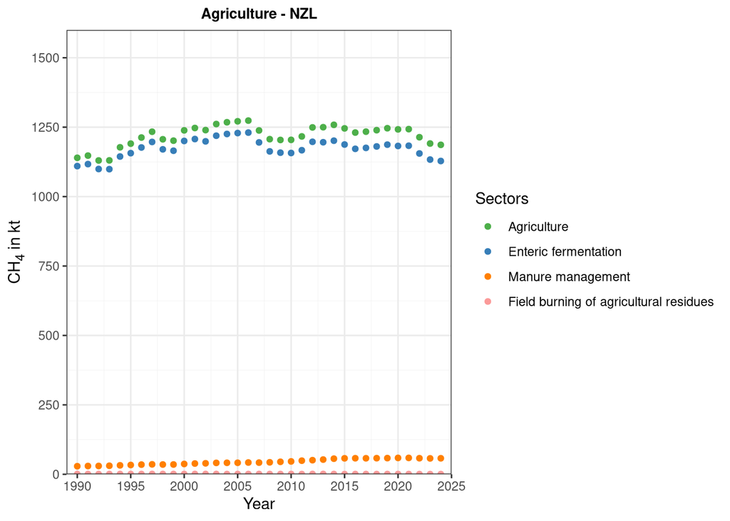

```r
NZL_CH4_AGR_Sec_NA_filt_plot <- Agriculture_sect_CC_specific_NA_filter_function(df = NZL_CH4_AGRICULTURE_Sector, lm = 1.6, br_lm = 2, bei = 0.25, CC = "NZL")

ggsave(file = here("04_visual/first_try/time_series/Emission_sectors/AGR_SEC", "AGR_sec_NZL_NA_filtered.pdf"),
       plot = NZL_CH4_AGR_Sec_NA_filt_plot)

NZL_CH4_AGR_Sec_NA_filt_plot
```

# All countries

### All Emission Sectors

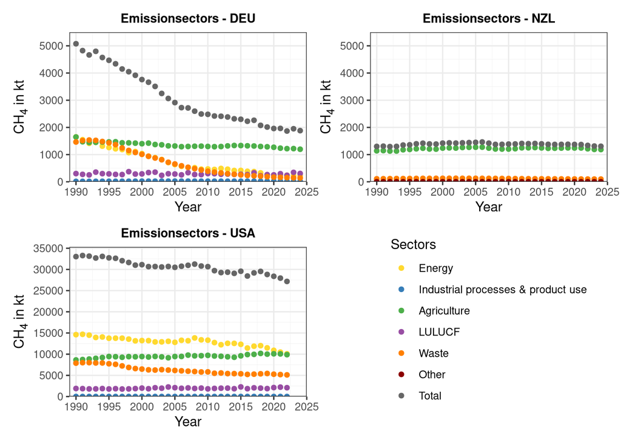

```r
All_CC_Emis_Sectors <- All_sectors_CC_specific_function(df = DEU_CH4_all_sectors, lm = 5.5, br_lm = 35, bei = 1, CC = "DEU") + All_sectors_CC_specific_function(df = NZL_CH4_all_sectors, lm = 5.5, br_lm = 35, bei = 1, CC = "NZL")  + All_sectors_CC_specific_function(df = USA_CH4_all_sectors, lm = 35.3, br_lm = 35, bei = 5, CC = "USA") +
  guide_area() +
  plot_layout(ncol = 2, guides = "collect")

ggsave(
  file = here("04_visual/first_try/time_series/Emission_sectors/All_Sectors", "All_sectors_ALL_CC.pdf"),
  plot = All_CC_Emis_Sectors
)

All_CC_Emis_Sectors
```

### Agriculture-Sector

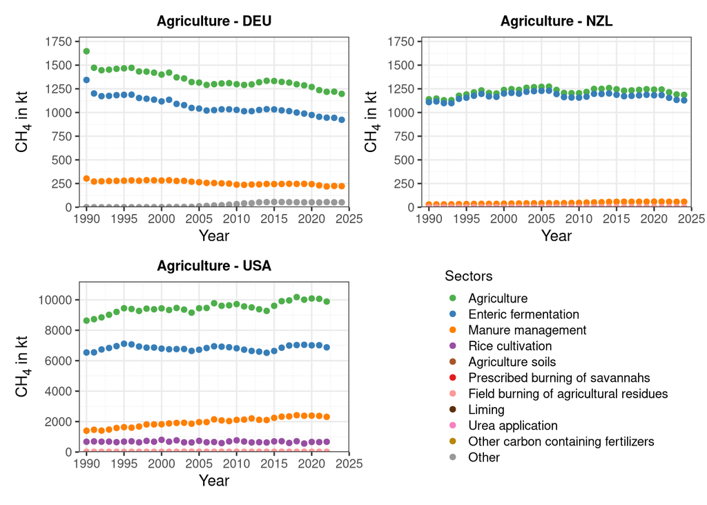

```r
AGR_CC_Emis_Sectors <- Agriculture_sect_CC_specific_function(df = DEU_CH4_Agric_Sect, lm = 1.8, br_lm = 2, bei = 0.25, CC = "DEU") + Agriculture_sect_CC_specific_function(df = NZL_CH4_AGRICULTURE_Sector,lm = 1.8, br_lm = 2, bei = 0.25, CC = "NZL")  + Agriculture_sect_CC_specific_function(df = USA_CH4_AGRICULTURE_Sector, lm = 11.2, br_lm = 12, bei = 2, CC = "USA") +
  guide_area() +
  plot_layout(ncol = 2, guides = "collect") &
  theme(
    legend.key.size = unit(0.4, "cm"),
    legend.text = element_text(size = 9),
    legend.title = element_text(size = 10)
  )

ggsave(
  file = here("04_visual/first_try/time_series/Emission_sectors/AGR_SEC", "AGR_sectors_ALL_CC.pdf"),
  plot = AGR_CC_Emis_Sectors
)

AGR_CC_Emis_Sectors
```